# Quantitative meta-analysis results

Amanida R package

23 March, 2022

## Data exploration

Data is loaded using `amanida_read` function:

```r
coln = c("Compound Name", "P-value", "Fold-change", "N total", "References")
input_file <- system.file("extdata", "dataset2.csv", package = "amanida")
datafile <- amanida_read(input_file, mode = "quan", coln, separator=";")
```

Your data:

```
## Loaded dataset with 143 rows which contains 120 different identifiers. There are 18 rows skipped from original dataset because contained NA values.
```

Here is shown the imported table:

Table 1: Data exploration

| ID | P-value | Fold-Change | Number of participants | Reference | Behaviour |
| --- | --- | --- | --- | --- | --- |
| Citric acid | 1.18e-03 | 3.07 | 342 | [24] Deng 2019 | Up-regulated |
| Citric acid | 7.90e-10 | 0.53 | 204 | [33] Cheng 2012 | Down-regulated |
| Citric acid | 1.90e-03 | 0.77 | 123 | [42] Qiu 2010 | Down-regulated |
| Citric acid | 4.32e-02 | 0.83 | 123 | [42] Qiu 2010 | Down-regulated |
| Citric acid | 1.00e-03 | 1.47 | 135 | [43] Liesenfeld 2015 | Up-regulated |
| Hippuric acid | 4.42e-04 | 0.39 | 342 | [24] Deng 2019 | Down-regulated |
| Hippuric acid | 5.70e-17 | 0.09 | 204 | [33] Cheng 2012 | Down-regulated |
| Hippuric acid | 9.60e-09 | 0.21 | 123 | [42] Qiu 2010 | Down-regulated |
| Indole-3-acetic acid | 2.06e-04 | 0.21 | 342 | [24] Deng 2019 | Down-regulated |
| Indole-3-acetic acid | 1.19e-09 | 0.34 | 204 | [33] Cheng 2012 | Down-regulated |
| Indole-3-acetic acid | 2.00e-03 | 0.80 | 135 | [43] Liesenfeld 2015 | Down-regulated |
| P-Cresol | 6.33e-10 | 0.28 | 204 | [33] Cheng 2012 | Down-regulated |
| P-Cresol | 2.00e-04 | 0.26 | 123 | [42] Qiu 2010 | Down-regulated |
| P-Cresol | 9.61e-02 | 1.40 | 123 | [42] Qiu 2010 | Up-regulated |
| 2-Aminobutyrate | 7.87e-09 | 1.75 | 204 | [33] Cheng 2012 | Up-regulated |
| 2-Aminobutyrate | 9.00e-09 | 1.29 | 135 | [43] Liesenfeld 2015 | Up-regulated |
| Guaiacol | 4.08e-02 | 0.43 | 60 | [29] Porto-Figueira 2018 | Down-regulated |
| Guaiacol | 2.80e-04 | 0.56 | 135 | [43] Liesenfeld 2015 | Down-regulated |
| L-Histidine | 6.01e-02 | 0.91 | 123 | [42] Qiu 2010 | Down-regulated |
| L-Histidine | 3.96e-02 | 1.30 | 123 | [42] Qiu 2010 | Up-regulated |
| L-Pyroglutamic acid | 2.03e-02 | 1.20 | 123 | [42] Qiu 2010 | Up-regulated |
| L-Pyroglutamic acid | 2.40e-03 | 1.30 | 123 | [42] Qiu 2010 | Up-regulated |
| L-Threonine | 2.00e-03 | 2.30 | 123 | [42] Qiu 2010 | Up-regulated |
| L-Tryptophan | 2.73e-07 | 0.63 | 204 | [33] Cheng 2012 | Down-regulated |
| L-Tryptophan | 1.00e-06 | 1.60 | 123 | [42] Qiu 2010 | Up-regulated |
| L-Tryptophan | 3.08e-02 | 1.20 | 123 | [42] Qiu 2010 | Up-regulated |
| L-Tyrosine | 2.57e-07 | 0.64 | 204 | [33] Cheng 2012 | Down-regulated |
| L-Tyrosine | 3.90e-03 | 1.60 | 123 | [42] Qiu 2010 | Up-regulated |
| L-Tyrosine | 1.00e-03 | 0.52 | 135 | [43] Liesenfeld 2015 | Down-regulated |
| Phenylacetic acid | 8.75e-02 | 1.20 | 123 | [42] Qiu 2010 | Up-regulated |

[output cut: 113 more lines]

## Quantitative analysis

Quantitative analysis is done for each different identifier. It combines the statistical significance and the effect size reported on the different studies, as follows:

- Statistical significance (p-value): Fisher’s method weigthed by number of participants on the study.
- Effect size (fold-change): logarithmic transformation for average with weighting by number of participants.

`compute_amanida` function is used to combine p-values and fold-change.

```r
amanida_result <- compute_amanida(datafile, comp.inf = params$comp_inf)
```

Here are shown your results:

```r
amanida_result@stat
```

Table 2: Quantitative analysis

| ID | Trend | P-value combined | Fold-change combined | Total sample size | reference |
| --- | --- | --- | --- | --- | --- |
| N1,N12-Diacetylspermine * | 1 | 3.60e-31 | 10.75 | 342 | [24] Deng 2019 |
| L-Proline | 1 | 4.04e-31 | 2.53 | 342 | [24] Deng 2019 |
| Kynurenic acid | -1 | 5.03e-27 | 0.40 | 204 | [33] Cheng 2012 |
| Hippuric acid * | -1 | 1.07e-24 | 0.22 | 669 | [24] Deng 2019; [33] Cheng 2012; [42] Qiu 2010 |
| D-Glucose | 1 | 1.90e-22 | 3.06 | 342 | [24] Deng 2019 |
| Tetradecenoyl carnitine (C14:1) | 1 | 3.19e-22 | 3.20 | 342 | [24] Deng 2019 |
| Glycolic acid | -1 | 1.56e-20 | 0.55 | 204 | [33] Cheng 2012 |
| Trimethylamine oxide | -1 | 2.84e-20 | 0.27 | 204 | [33] Cheng 2012 |
| L-Histidinol * | 1 | 2.76e-19 | 12.76 | 204 | [33] Cheng 2012 |
| Homovanillic acid | -1 | 1.05e-17 | 0.51 | 204 | [33] Cheng 2012 |
| Pyruvic acid * | -1 | 5.70e-17 | 0.09 | 204 | [33] Cheng 2012 |
| 2-Hydroxyestradiol | -1 | 8.08e-17 | 0.31 | 204 | [33] Cheng 2012 |
| L-Kynurenine | 1 | 6.53e-16 | 3.50 | 342 | [24] Deng 2019 |
| Uridine | -1 | 8.14e-16 | 0.59 | 204 | [33] Cheng 2012 |
| 2-Aminobutyrate | 1 | 2.85e-15 | 1.55 | 339 | [33] Cheng 2012; [43] Liesenfeld 2015 |
| Pyridoxal | -1 | 3.57e-15 | 0.25 | 204 | [33] Cheng 2012 |
| Citric acid | 1 | 1.38e-14 | 1.31 | 927 | [24] Deng 2019; [33] Cheng 2012; [42] Qiu 2010; [42] Qiu 2010; [43] Liesenfeld 2015 |
| Indole-3-acetic acid | -1 | 3.83e-13 | 0.32 | 681 | [24] Deng 2019; [33] Cheng 2012; [43] Liesenfeld 2015 |
| L-Tryptophan | -1 | 4.08e-12 | 0.97 | 450 | [33] Cheng 2012; [42] Qiu 2010; [42] Qiu 2010 |
| P-Cresol | -1 | 4.56e-12 | 0.43 | 450 | [33] Cheng 2012; [42] Qiu 2010; [42] Qiu 2010 |
| D-Glucuronic Acid | -1 | 5.20e-12 | 0.61 | 204 | [33] Cheng 2012 |
| Myristic acid | -1 | 6.38e-12 | 0.33 | 204 | [33] Cheng 2012 |
| Phenol | -1 | 1.25e-11 | 0.27 | 264 | [29] Porto-Figueira 2018; [33] Cheng 2012 |
| N-alpha-Acetyl-L-lysine | -1 | 1.25e-11 | 0.49 | 204 | [33] Cheng 2012 |
| 3-(3-Hydroxyphenyl)-3-hydroxypropanoic acid | -1 | 9.44e-11 | 0.33 | 342 | [24] Deng 2019 |
| Putrescine | 1 | 1.22e-10 | 2.74 | 546 | [24] Deng 2019; [33] Cheng 2012 |
| L-Tyrosine | -1 | 3.45e-10 | 0.77 | 462 | [33] Cheng 2012; [42] Qiu 2010; [43] Liesenfeld 2015 |
| L-Aspartic acid | -1 | 5.73e-10 | 0.32 | 342 | [24] Deng 2019 |
| Threonic acid | -1 | 7.25e-10 | 0.74 | 204 | [33] Cheng 2012 |
| Uracil | -1 | 7.78e-10 | 0.63 | 204 | [33] Cheng 2012 |

[output cut: 90 more lines]

* Value over cut-offs

*Note: * indicates the result is statistical significant*

### Significant results for quantitative analysis

The cut-off selected by the user for significant results are:

- p-value: 0.05.
- fold-change: 4 for up-regulated and 0.25 for down-regulated.

Using indicated cut-offs there are **14** compounds significant, 4 up-regulated and 10 down-regulated compounds.

### Graphical results

To see graphically the results obtained is used `volcano_plot`:

With /Users/maria/OneDrive - URV/metaanalysis_pack/inst/extdata/dataset2.csv and a p-value cut-off of 0.05 and fold-change cut-off of 4 (up-regulated) or 0.25 (down-regulated):

```
## The cut-off used are 0.05 for p-value (1.3 in log10 scale) and 4 for fold-change (2 in log2 scale).
```

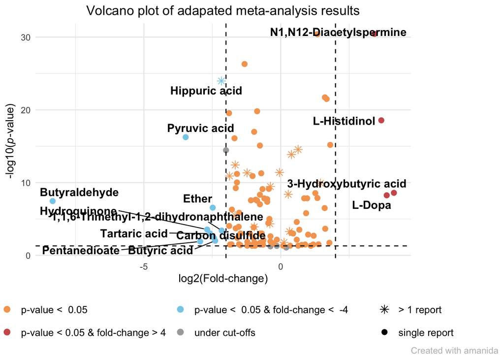

```r
volcano_plot(amanida_result, cutoff = c(params$pvalue_cutoff, params$fc_cutoff))
```

*Note: labeled compounds are the ones found significant for the cut-off indicated*

Discrepancies on the results obtained are evaluated comparing the number of articles where an element is found up-regulated and down-regulated. It is also ploted the total results, as vote-counting, obtained by the difference between up-regulated and down-regulated number of reports.

Here, the explore_plot will only display the relevant identifiers (elements bigger than number of votes specified) or those with discrepancies between studies.

As dataset is big, on the following plot will be only displayed elements bigger than 2 votes and the elements with discrepancies between studies:

```
## Cut-off for votes is 2.
```

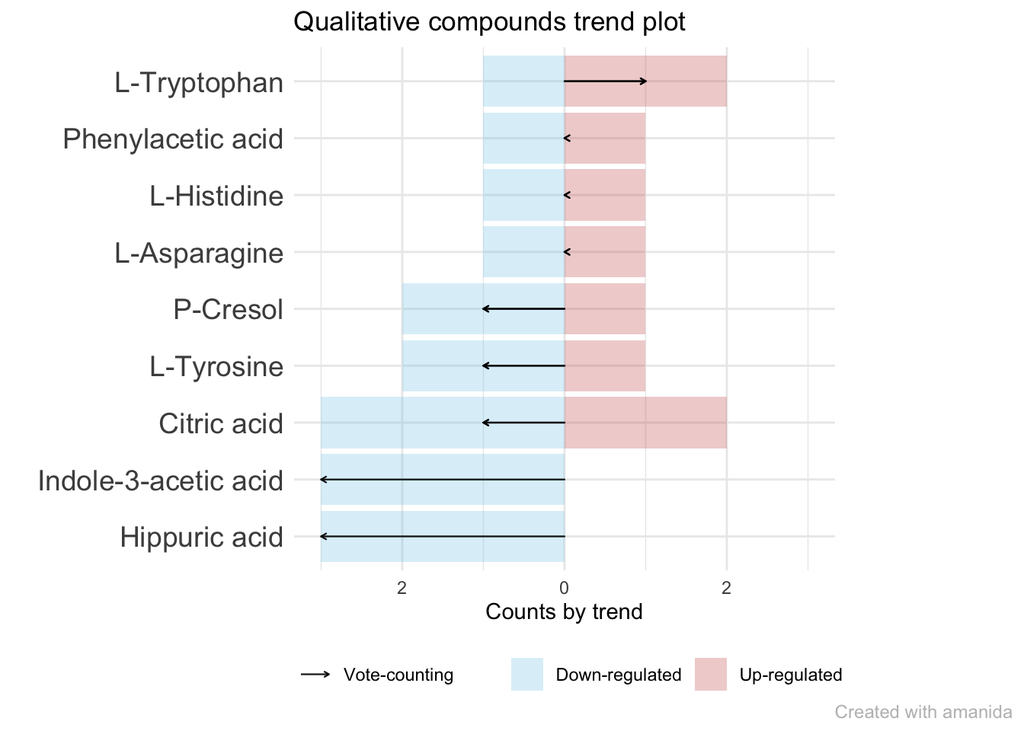

```r
amanida::explore_plot(datafile, type = "mix", params$votecount_lim)
```

*Note: Plots are limited to 30 compounds for readability, for complete plot download from ubidi.shinyapps.io/easy-amanida*

It is important to check if our significant compounds have discrepancies on the reports.

*Qualitative analysis using Amanida R package*